# Printability

## Literature review

- Last update: “2019-12-18”
- Work document for Anezka research.

> **Goal**: The main goal of this document is to make a systematic literature review about the notion ‘Printability’ from a rheology perspective

> *Specific goals:*
> - Definition of printability from literature.
> - Map the rheology measurements used in 3D printing. Establish what correlations of rheology to printing process.
> - Identify requirements to consider for an open source hardware.

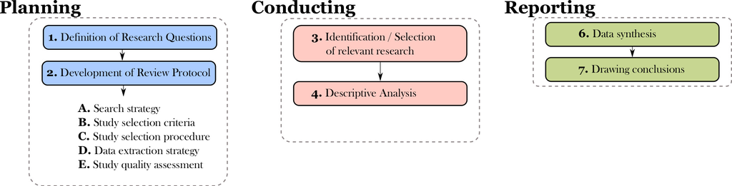

Methodology for the search of literature

## Planning

### Review protocol

1. **Type of doucments:** Only journals
2. **Keywords:**
   - fused deposition modelling, fused filament fabrication, 3D printing
   - rheology, viscosity
   - polymer
3. **Search strategy**
   - (“fused deposition modeling” OR “3D printing” OR “fused filament fabrication”) AND (rheology OR viscosity) AND “polymer”)
4. **Datbases:** Web of Science
5. **Study selection criteria**
   - Papers related to engineering
6. **Study selection procedure**
   - First filter: Read Title and Abstract
   - Second : Read intro and conclusions

## Conducting

### Total documents retrieved: 204

|  | Title | Abstract | Year | DOI | Journal |
| --- | --- | --- | --- | --- | --- |
| 2 | 3D printing of polymer-bonded magnets from highly concentrated, plate-like particle suspensions | This paper reports the 3D printing of polymer-bonded magnets using highly concentrated suspensions of non-spherical magnetic particles. In a previous study, magnets of arbitrary shapes have been succe… | 2019 | 10.1016/j.matdes.2019.108133 | MATERIALS & DESIGN |
| 3 | 3D Printing of Supramolecular Polymers: Impact of Nanoparticles and Phase Separation on Printability | 3D printing of linear and three-arm star supramolecular polymers with attached hydrogen bonds and their nanocomposites is reported. The concept is based on hydrogen-bonded supramolecular polymers, kno… |  | 10.1002/marc.201900467 | MACROMOLECULAR RAPID COMMUNICATIONS |
| 4 | Preparation of Thermoplastic Polyurethane Parts Reinforced with in Situ Polylactic Acid Microfibers during Fused Deposition Modeling: The Influences of Deposition-Induced Effects | 3D printing technologies have exhibited their superiorities in the polymer processing field. In this work, thermoplastic polyurethane (TPU)-based soft parts reinforced with in situ polylactic acid (PL… | 2019 | 10.1021/acs.iecr.9b04285 | INDUSTRIAL & ENGINEERING CHEMISTRY RESEARCH |
| 5 | 3D printed polymers are less stable than injection moulded counterparts when exposed to terminal sterilization processes using novel vaporized hydrogen peroxide and electron beam processes | There is an increasing trend for use of 3D printing processes in healthcare due in part to emergence of customised medical devices and associated low manufacturing cost. However, there is a dearth of … | 2019 | 10.1016/j.polymer.2019.121870 | POLYMER |
| 6 | Atomization of cellulose nanocrystals aqueous suspensions in fused deposition modeling: A scalable technique to improve the strength of 3D printed polymers | 3D printed polymer parts remain too low in mechanical performance that inhibits their industrial applications. We introduce a novel and scalable technique to enhance the strength of 3D printed polymer… | 2019 | 10.1016/j.compositesb.2019.107291 | COMPOSITES PART B-ENGINEERING |
| 7 | Fabrication of microfiltration membranes from polyisobutylene/polymethylpentene blends | An approach for fabrication of microfiltration membranes by solvent extraction of one of the immiscible components from a polymer blend was developed. Poly(4-methyl-1-pentene) (PMP) was the membrane m… |  | 10.1002/pi.5932 | POLYMER INTERNATIONAL |
| 8 | Estimating Powder-Polymer Material Properties Used in Design for Metal Fused Filament Fabrication (DfMF(3)) | Metal fused filament fabrication (MF3) combines fused filament fabrication and sintering processes to fabricate complex metal components. In MF3, powder-polymer mixtures are printed to produce green p… |  | 10.1007/s11837-019-03920-y | JOM |
| 9 | Immersion precipitation 3D printing (ip3DP) | Fabrication of controlled porous materials has gained interest because of their broad range of applications in energy storage, catalysis, biotechnology, and life sciences. The recent development of 3D… | 2019 | 10.1039/c9mh00730j | MATERIALS HORIZONS |
| 10 | Facile fabrication and characterization of highly stretchable lignin-based hydroxyethyl cellulose self-healing hydrogel | In this study, hydroxyethyl cellulose (HEC) and polyvinyl alcohol (PVA) as the framework, borax as the crosslinker, and biomass lignin from pulping black liquors and biorefinery as the plasticizer wer… | 2019 | 10.1016/j.carbpol.2019.115080 | CARBOHYDRATE POLYMERS |
| 11 | Role of pendant side-chain length in determining polymer 3D printability | Three-dimensional (3D) printing allows for creation of patient-specific implants. However, development of new synthetic materials for 3D printing has been relatively slow with only a few polymers avai… | 2019 | 10.1039/c9py00879a | POLYMER CHEMISTRY |

[output cut: 194 more lines]

### Selection of Relevant articles

Selected documents: 28

|  | Title | Abstract | Year | Material | Type.of.Rheology.Measurement | Conclusions | DOI |
| --- | --- | --- | --- | --- | --- | --- | --- |
| 1 | Rapid Open-Air Digital Light 3D Printing of Thermoplastic Polymer | 3D printing has witnessed a new era in which highly complexed customized products become reality. Realizing its ultimate potential requires simultaneous attainment of both printing speed and product v… | 2019 | termoplastics with 4-acryloylmorpholine (ACMO) | • MFI (CEAST 10060 ROLETTO T = 220 °C with a 2.16 kg load | • MAX MFI = 54g/10min - beyond that printability was lost • Tg above printing temperature | 10.1002/adma.201903970 |
| 2 | Acrylate-based photosensitive resin for stereolithographic three-dimensional printing | In this article, we report an acrylate-based three-dimensional (3D) printing stereolithography rapid-prototyping photosensitive resin with a low viscosity, small volumetric shrinkage, high photoreacti… | 2019 | acrylate resins | • rotational rheometer (Haake RS1) with 60 mm parallel plates; gap = 1 mm -->dynamic temperature tests (oscillatory temperature ramps) = 25 - 80 °C with a heating rate of 2 °C/min --> exploring the de… | • viscosity is one of the most important parameters indicating the fluidity and printability of photosensitive resins • low viscosity is required for SLA printing --> for high printing efficiency and … | 10.1002/app.47487 |
| 3 | Microscopic morphology, rheological behavior, and mechanical properties of polymers: Recycled acrylonitrile-butadiene-styrene/polybutylene terephthalate blends | In this study, styrene-acrylonitrile-glycidyl methacrylate (SAG) series copolymers were specially designed for producing the recycled acrylonitrile-butadiene-styrene (rABS)/poly(butylene terephthalate… | 2020 | rececycled ABS/PET blends with SEG | • rotational rheometer (MCR 302, Anton Paar, Austria) parallel plate geometry --> diameter 25 mm gap between the upper and lower plates = 0.1 mm; T = 250 °C; frequency = 0.0628 to 628 rad/s; strain am… | • theoretical evaluation of recycled ABS/PET blends with SEG • evaluation of composition of the blends and their THEORETICAL use for FDM | 10.1002/app.48310 |
| 4 | Synthesis and Properties of Polyetheretherketones for 3D Printing | Polyetheretherketones (PEEKs) of different molecular masses were synthesized via high-temperature polycondensation using nucleophilic substitution by varying the excess of 4,42-difluorobenzophenone. T… | 2018 | PEEK | • MFI (IIRT-5 capillary viscometer) T = 350°C; load = 5 kg | • evaluation of the properties of newly synthesized materials --> MFI of the polymer is one of the most important parameters controlling the ability to use polymers in 3D printing --> it depends direc… | 10.1007/s10692-018-9911-5 |
| 5 | Recycled polyethylene terephthalate as a new FFF feedstock material | Reclaimed materials such as waste plastics can be utilized in additive manufacturing to improve the self-reliance of war fighters on forward operating bases by cutting costs and decreasing the demand … | 2018 | 100% recycle PET commercial PET | • rotational rheometer (AR2000) parallel aluminum plates of diameter 25mm, gap = 1000 μm; T= 270 °C shear rate = 1 s−1; ramp = 0.1 to 100 s−1 | • rPET - good for 3D printing - half of the quality than injection molding | 10.1016/j.addma.2018.03.007 |
| 6 | Nozzle clogging factors during fused filament fabrication of spherical particle filled polymers | Fused filament fabrication with reinforced or filled polymers provides improved material properties compared to ordinary feedstock. A current limitation of these materials is the occurrence of nozzle … | 2018 | polycarbonates filled with glassy spheres | • MFI = pressurized - air driven nozzle flow test device | • testing nozzle clogging --> designed their own device (similar to MFI) - comparing nozzle diamter with fillers ratio • NO OTHER TESTING | 10.1016/j.addma.2018.08.009 |
| 7 | High-throughput characterization of fluid properties to predict droplet ejection for three-dimensional inkjet printing formulations | Inkjet printing has been used as an Additive Manufacturing (AM) method to fabricate three-dimensional (3D) structures. However, a lack of materials suitable for inkjet printing poses one of the key ch… | 2019 | acrylates/methacrylates | • rotational rheometer - high-throughput screening (HTS) | • 3D inject printing 20 - 40 mPa.s (dynamic viscosity) --> materials beyond that = non printable | 10.1016/j.addma.2019.100792 |
| 8 | general method to improve 3D-printability and inter-layer adhesion in lignin-based composites | We report the utilization of a melt-stable lignin waste-stream from biorefineries as a renewable feedstock, with acrylonitrile-butadiene rubber and acrylonitrile-butadiene-styrene (ABS) polymer to syn… | 2018 | compoistes of acrylonitrile-butadiene rubber and acrylonitrile-butadiene-styrene (ABS) + lignin | • rotational rheometer (Discovery Hybrid Rheometer (DHR-3, TA instruments) nitrogen atmosphere 8 mm diameter parallel plates with a sample gap of ca. 0.4 mm; Strain sweeps = 10 rad/s --> determine the… | • good 3D-printability --> shear rate and viscosity of ca. 190 s−1 to 3000 s−1 and ca. 70 Pa s to 500 Pa s; • for 3D-printing --> high zero-shear viscosity or high flow resistance in the terminal regi… | 10.1016/j.apmt.2018.03.009 |
| 9 | Bioinspired 3D printable pectin-nanocellulose ink formulations | The assessment of several ink formulations for 3D printing based on two natural macromolecular compounds is presented. In the current research we have exploited the fast crosslinking potential of pect… | 2019 | pectin - nanocellulose gels | • rotational rheometer (Kinexus Pro) cone - plate geometry with 4°angle and diammeter 40mm; shear rate = 0.01–1000 s−1 at 25°C | • improving the gel printability providing a high printing fidelity --> shear-thinning phenomenon = viscosity progressively decreases as the shear rate increases •observing composition of the material… | 10.1016/j.carbpol.2019.05.026 |
| 10 | What makes a material printable? A viscoelastic model for extrusion-based 3D printing of polymers | This article presents a practical model for evaluating polymer feedstock materials as candidates for 3D printing across a variety of extrusion-based platforms. In order for a material to be successful… | 2018 | ABS PP | • rotational rheometers - shear rate • capillary viscosimeter - pressure drop • MFI - volume rate | • material must be forced through an orifice at a given rate at a pressure that is below the system limit • primarily depends on the viscosity of the material at the operating shear rate --> it has to… | 10.1016/j.jmapro.2018.08.008 |

[output cut: 18 more lines]

## Reporting

### MFI as a Printability quality Parameter

A polymer material characteristic such as branching degree, configurational stereochemistry, molar mass distribution and quantity of additives affect its flow behavior and therefore material’s printing ability.

For controlling and predicting the whole printing process, specific material parameters can be measured, namely the **melting temperature, the melt viscosity, the glass transition temperature, material heat capacity or its shear stress**.

There are three conventional ways for measuring thermoplastic polymers viscosity:

1. rotational rheometer
2. high – pressure capillary viscosimeter and
3. melt flow indexer (MFI).

The first two methods provide material flow behavior in different conditions and therefore also give the plot of viscosity dependence on different measured material parameters, e.g. shear stress, pressure, melt flow rate, etc. Due to these plotted dependences, it is possible to determine the *material’s shear – thinning behavior which is usually one of the first indications whether is the material printable or not*. Based on these viscosity characterizations, the rotational rheometers, and high – pressure capillary viscosimeters are the most commonly used methods for determining the material ability for 3D printing.

To the best of my knowledge, **there are just a few papers in the literature (Web of Science), that presented only MFI from possible rheological methods as a printability quality parameter.** In addition to measuring rheological behavior using MFI, other material characterization methods that could predict the material’s 3D printing ability (e.g. Tg) were used.

The question of whether is MFI suitable indicator to predict material’s 3D printability was tried to answer by a team of researchers from Ghent University. The melt flow index provides information about ease of the flow of the molten thermoplastic polymer. The higher the index is, the less is material viscous. According to the researchers, MFI correlates with the 3D printing process, interlayer adhesion and properties of the final printed product [1,2] Their research was focused on several commercially available PLA materials/filaments. It has been shown that for 3D printing of PLA filament is necessary to achieve at least MFI value of 10g/10min. This corresponds to a sufficient 3D printing process and final product quality. For achieving this minimal MFI value, it is possible to slightly adjust the melting temperature of the material [2]. Since the MFI values of commercial thermoplastics are usually given by manufacturers, this method could quickly and efficiently evaluate the material’s viscosity and therefore indicate their 3D printability. And yet I have not found an article in which would describe using MFI characterization of recycled polymers for 3D printing.

**References**

- [1] Shenoy, V.; Saini, D. Melt Flow Index: More Than Just a Quality Control Rheological Parameter. Part Il*. Adv. Polym. Technol. 1986, 6 (2), 125–145.
- [2] Sisi Wang, Lore Capoen, Dagmar R. D’hooge & Ludwig Cardon (2017): Can the melt flow index be used to predict the success of fused deposition modelling of commercial poly(lactic acid) filaments into 3D printed materials?, Plastics, Rubber and Composites, DOI: 10.1080/14658011.2017.1397308

## Practical side

We have been working on Onshape software:

Here a cut version of proposed model so far

Main elements to highligth:

- Use aluminium

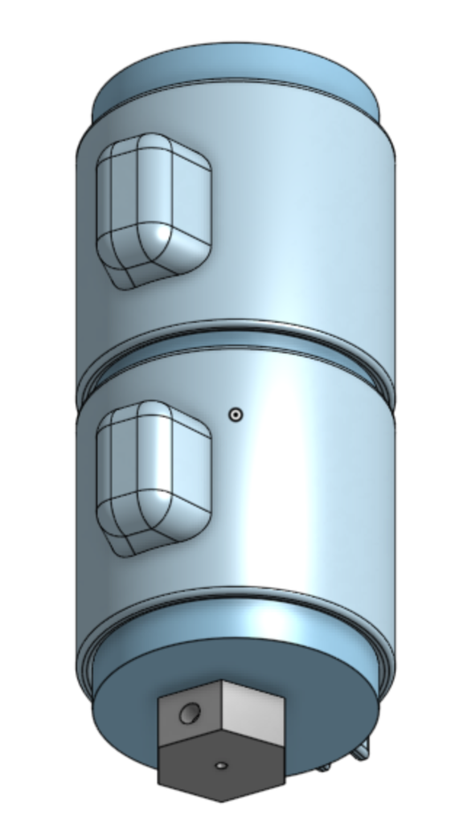

Open source MFI - Version beta 1

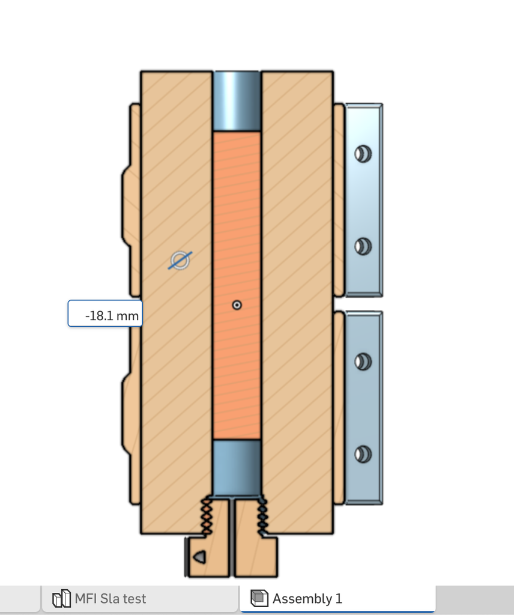

Open source MFI - Cutted view beta 1

# Next steps?

## Research aspect:

Prototype: - rack/holder for the chamber - insulation of the chamber - electronics - thermal sensor and heating